# Introduction to transport data science

Robin Lovelace University of Leeds

[figure not shown]

## Thinking about (transport) data science

- How do you see yourself using data science over the next 5 years?
- Think of a question about a transport system you know well and how data science could help answer it, perhaps with reference to a sketch like that below

#### How much potential is there for cycling across the transport network?

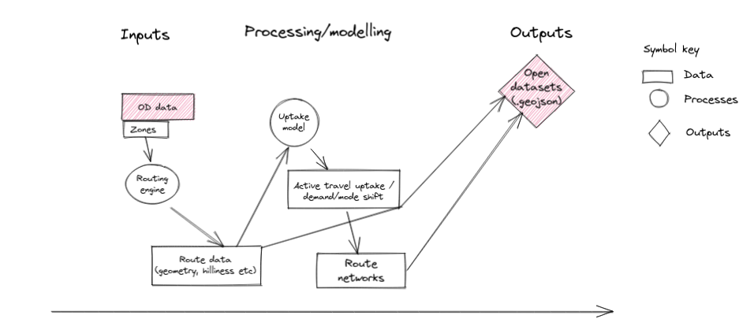

#### How can travel to schools be made safer?

#### How can hospitals encourage visitors to get there safely?

#### Where’s the best place to build electric car charging points?

See https://www.openstreetmap.org/#map=19/53.80689/-1.55637 for more ideas

# 1 R foundations

This section builds on the Reproducible road safety with R homework, to **read and try to complete the exercises in Chapters 1 to 4 of the book Reproducible Road Safety Research with R.** It assumes that you have recently updated R and RStudio on your computer. For details on installing packages see here: https://docs.ropensci.org/stats19/articles/stats19-training-setup.html

- Create a new R project called ‘practical1’
- In it create file called foundations.Rmd
- Type the following

````markdown
This is some text:


```r
casualty_type = c("pedestrian", "cyclist", "cat")
casualty_age = seq(from = 20, to = 60, by = 20)
crashes = data.frame(casualty_type, casualty_age)
```
````

- Knit the document by pressing Ctrl+Shift+K or with the ‘Knit’ button in RStudio
  - Bonus: you can also ‘knit’ or compile the file with the following command, try it out to generate different file formats, as described in the [package’s documentation](https://rmarkdown.rstudio.com/lesson-9.html):

```r
rmarkdown::render("foundations.Rmd", output_format = "pdf_document")
browseURL("/tmp/foundations.pdf")
```

We now have a data frame object stored in memory (technically in the global environment) that is used as the basis of the questions.

To get some larger datasets, try the following (from Chapter 8 of RSRR)

```r
library(stats19)
ac = get_stats19(year = 2019, type = "collision")
```

[output not shown]

```r
ca = get_stats19(year = 2019, type = "cas")
```

```
## Files identified: dft-road-casualty-statistics-casualty-2019.csv
##
##    https://data.dft.gov.uk/road-accidents-safety-data/dft-road-casualty-statistics-casualty-2019.csv
## Attempt downloading from: https://data.dft.gov.uk/road-accidents-safety-data/dft-road-casualty-statistics-casualty-2019.csv
## Data saved at /tmp/RtmpRpYa1T/dft-road-casualty-statistics-casualty-2019.csv
```

```r
ve = get_stats19(year = 2019, type = "veh")
```

```
## Files identified: dft-road-casualty-statistics-vehicle-2019.csv
##
##    https://data.dft.gov.uk/road-accidents-safety-data/dft-road-casualty-statistics-vehicle-2019.csv
## Attempt downloading from: https://data.dft.gov.uk/road-accidents-safety-data/dft-road-casualty-statistics-vehicle-2019.csv
## Data saved at /tmp/RtmpRpYa1T/dft-road-casualty-statistics-vehicle-2019.csv
```

[output not shown]

2.3.2. Subsetting the crashes with the `[,]` syntax

```
- Try out different combinations on the dataframe
```

2.3.3. **Bonus**: what is the `class()` of the objects created by each of the previous exercises?

```
- Explore how many R classes you can find
```

Let’s go through these exercises together:

## 1.1 Bonus: reproduce the contents of Chapter 2 in Python

# 2 Practical introduction to data science

## 2.1 Completing Chapters 2-4 in the RRSRR document

- This was your homework but revisit it an ensure you understand every bit and complete it if you haven’t already

## 2.2 Tidyverse

- Work through Chapter 5 starting with the following code:

```r
library(tidyverse) # Load the package
```

# 3 Homework

- Work through chapters 6 and 7 on spatial and temporal data in the [RRSRR tutorial](https://itsleeds.github.io/rrsrr/) to get R foundations
- Work-through the remaining exercises of the first sections in R4DS chapters 3 and 5
  - Write your notes in a .R, .Rmd or .qmd file with comments, to show your working (and prove you’ve done it!)
- **Bonus 1 (optional)** Run the code in the demos/demo-quarto-document.qmd script

Note: you can copy-paste the code from the .qmd file into a new .qmd file on your computer and render it (convert it into a .PDF file) using the following:

```r
install.packages("quarto")
```

```r
quarto::quarto_render("demos/demo-quarto-document.qmd")
```

**Bonus 2 (optional for this week, advised at some point over the next 4 weeks at your own pace)**

Work through all of the code in the [RRSRR tutorial](https://itsleeds.github.io/rrsrr/), focussing on the parts that you think will be most useful for your coursework.

## 3.1 Bonus: Analysis of flights data

You need to have a number of packages installed and loaded. Install the packages by typing in the following commands into RStudio (you do not need to add the comments after the `#` symbol):[^1]

```r
install.packages("remotes")
pkgs = c(
  "nycflights13",# data package
  "stats19",     # downloads and formats open stats19 crash data
  "tidyverse"   # a package for user friendly data science
)
remotes::install_cran(pkgs)
remotes::install_github("nowosad/spDataLarge")
```

Load the tidyverse package as follows:

```r
library(tidyverse)
```

- Read [section 5.1](https://r4ds.had.co.nz/transform.html#filter-rows-with-filter) of R for Data Science and write code that reproduces the results in that section in the script `learning-tidyverse.R`

Your script will start with something like this:

```r
library(tidyverse)
library(nycflights13)
```

- Take a random sample of 10,000 flights and assign it to an object with the following line of code:

```r
library(nycflights13)
flights_sample = sample_n(flights, 1e4)
unique(flights$carrier)
```

```
##  [1] "UA" "AA" "B6" "DL" "EV" "MQ" "US" "WN" "VX" "FL" "AS" "9E" "F9" "HA" "YV"
## [16] "OO"
```

- Find the unique carriers with the `unique()` function
- Create an object containing flights from United, American, or Delta, and assign it to `f`, as follows:

```r
f = filter(flights, grepl(pattern = "UA|AA|DL", x = carrier))
f2 = filter(flights, grepl(pattern = "UA", x = carrier) |
             grepl(pattern = "AA", x = carrier) |
             grepl(pattern = "DL", x = carrier)
           )
f3 = filter(flights, str_detect(carrier, "UA|AA|DL"))
```

- Create plots that visualise the sample flights, using code from Chapter 3 of the same book, starting with the following plot:

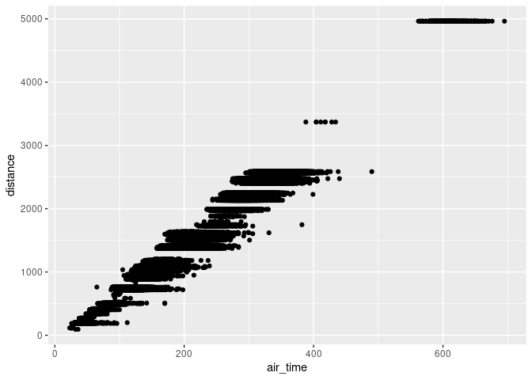

```r
ggplot(f) +
  geom_point(aes(air_time, distance))
```

- Add transparency so it looks like this (hint: use `alpha =` in the `geom_point()` function call):

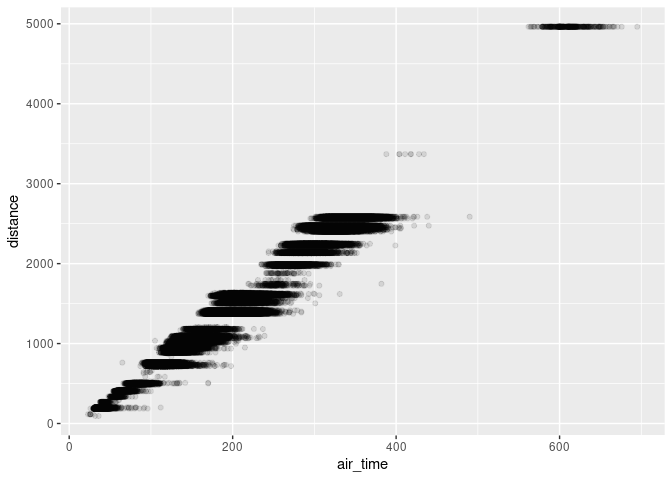

- Add a colour for each carrier, so it looks something like this:

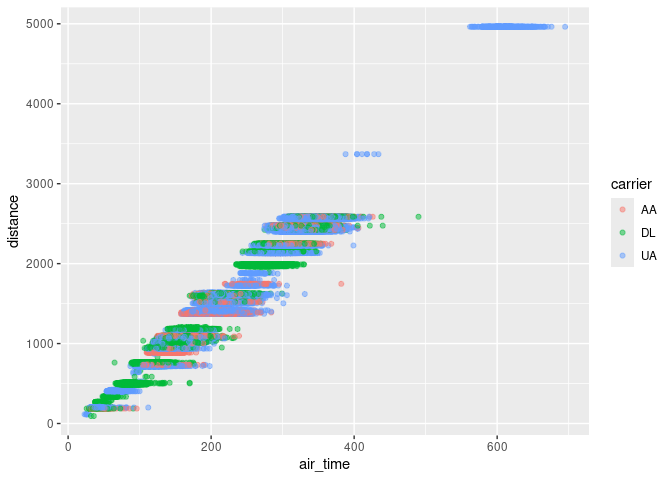

```r
ggplot(f) +
  geom_point(aes(air_time, distance, colour = carrier), alpha = 0.5)
```

- Bonus 1: find the average air time of those flights with a distance of 1000 to 2000 miles
- Bonus 2: use the `lm()` function to find the relationship between flight distance and time, and plot the results (start the plot as follows, why did we use `na.omit()`? hint - find help with `?na.omit()`):

```r
f = na.omit(f)
m = lm(air_time ~ distance, data = f)
f$pred = m$fitted.values
```

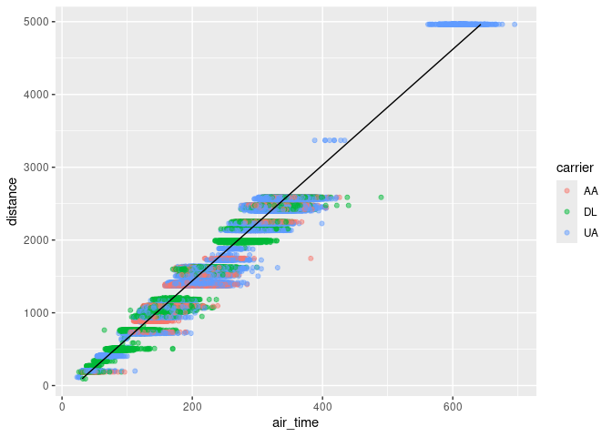

[^1]: Note: if you want to install the development version of a package from GitHub, you can do so. Try, for example, running the following command: `remotes::install_github("ITSLeeds/pct")`